# Decomposition and ARIMA

Şeyma Çakır

2021-06-06

# Time Series Decomposition and Forecasting with ARIMA

## Introduction

The Forecasting Energy Consumption is a key factor to construct energy market in energy markets since price of energy is determined before consumption. [EPIAS](https://seffaflik.epias.com.tr/transparency/tuketim/gerceklesen-tuketim/gercek-zamanli-tuketim.xhtml) is a platform that provide data of hourly electricity consumption of Turkey to operate and develop energy markets in an effective, transparent and sustainable manner. The report explains the methods which I used for predicting hourly electricity consumption of the Turkey for next two week. The data provided by [EPIAS](https://seffaflik.epias.com.tr/transparency/tuketim/gerceklesen-tuketim/gercek-zamanli-tuketim.xhtml) is contains hourly electricity consumption of Turkey from 1 January 2016 to 20 May 2021. The aim of the study is to transform data to stationary series and use this series in AR and MA models to select best fit model by comparing them.

## Data Manipulation

The graph is below shows electricity consumption of Tukey from 1 January 2016 to 20 May 2021. Since zero consumption is nor a realistic case the data manipulated to eliminate effect of zero consumption by changing zero consumption with mean of consumption before one hour ago and one hour later. There is a clear seasonality and slightly trend. It is colored by seansons, since there is a clear increase in beginning of winter and summer. It can be reason that winter is cold in Turkey and Summer is hot. The electricity can be used for heating-cooling and the day length depends on seasons.

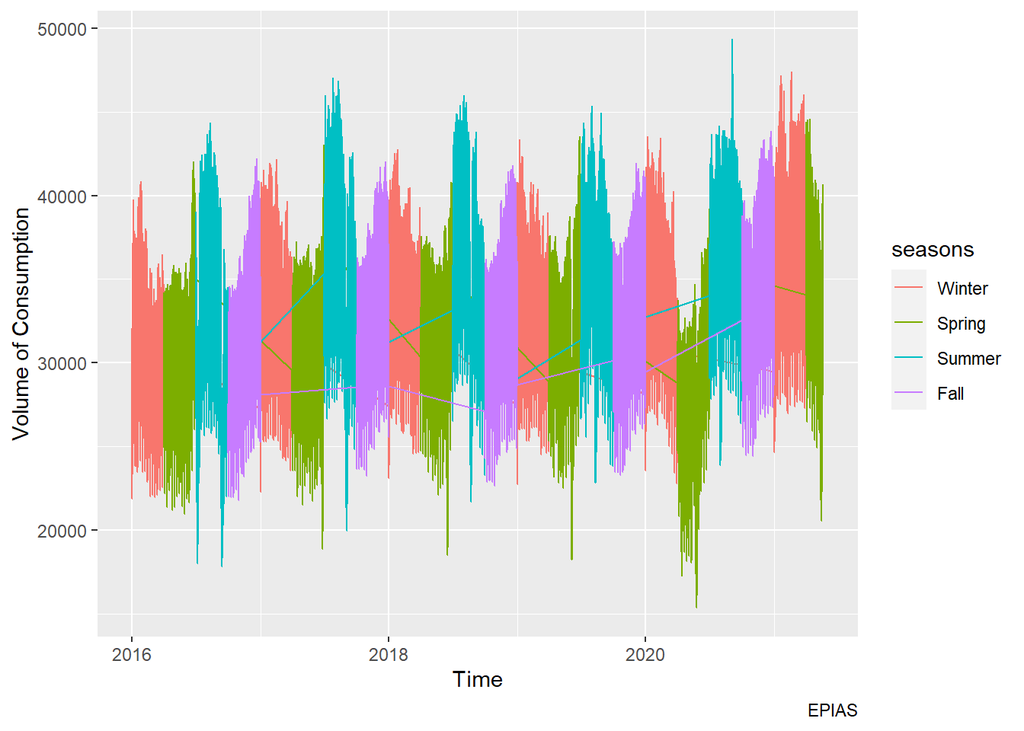

## Seasonality and Decomposition

### Hourly Electricity Consumption

I decomposed the hourly data by both type (additive and multiplicative) and the result of decompose show that the additive method give more stationary data. After subtracting seasonal component and trend component, it is observed that ACF shows sinusoidal geometric shape and there is sharp decrease after lag 1 in the PACF graph therefore AR model can be suitable.

```
## [1] "the addtive model"
```

```
##
## #######################################
## # KPSS Unit Root / Cointegration Test #
## #######################################
##
## The value of the test statistic is: 3e-04
```

```
## [1] "the multiplicative model"
```

```
##
## #######################################
## # KPSS Unit Root / Cointegration Test #
## #######################################
##
## The value of the test statistic is: 0.513
```

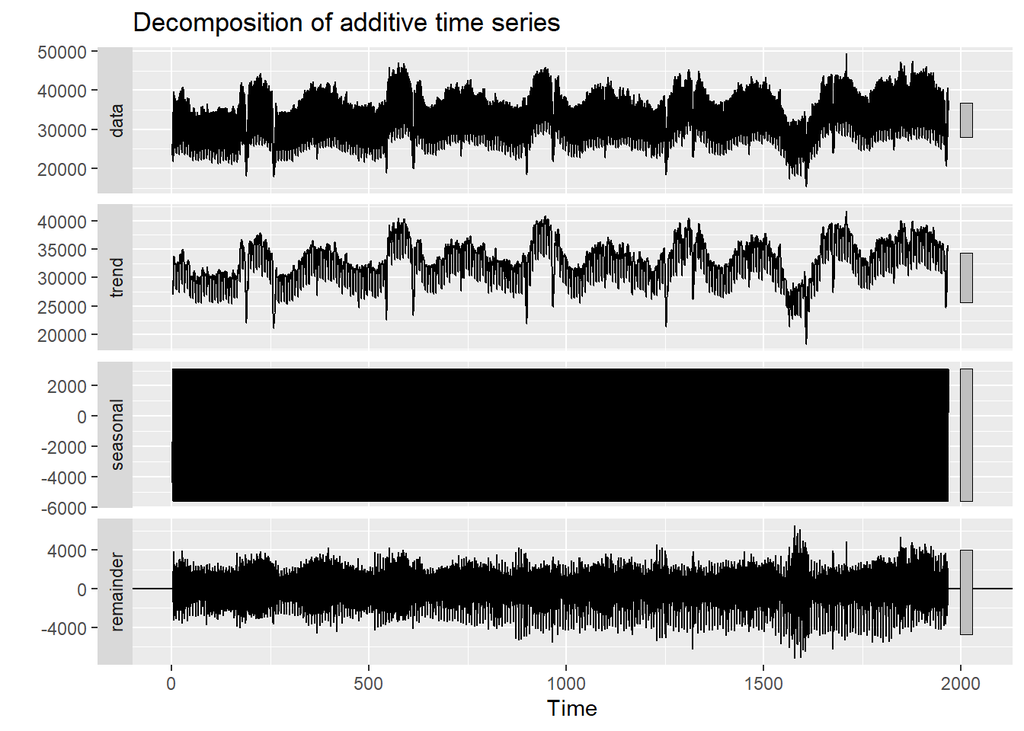

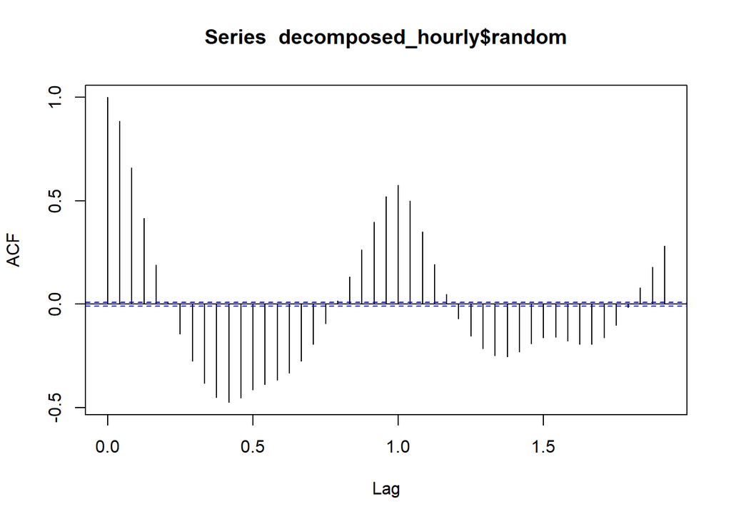

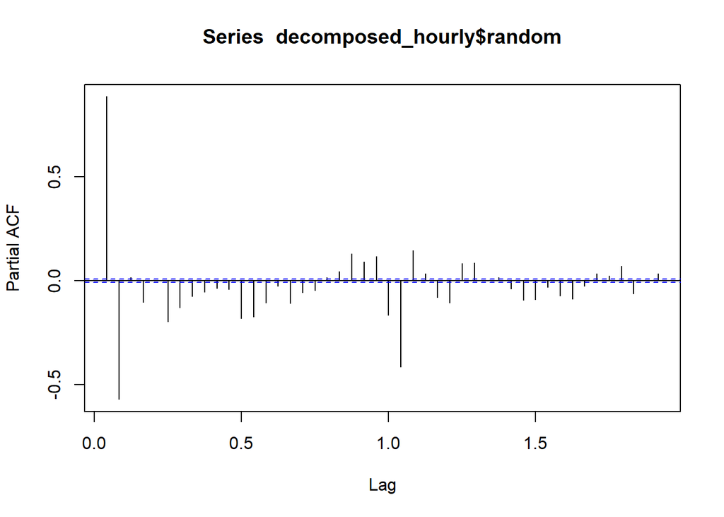

### Daily Electicity Consumption

The Daily Electricity Consumption of Turkey calculating by sum of all day consumption. The line graph below shows electricity consumption of 21 days and it is observed that there is a pattern.

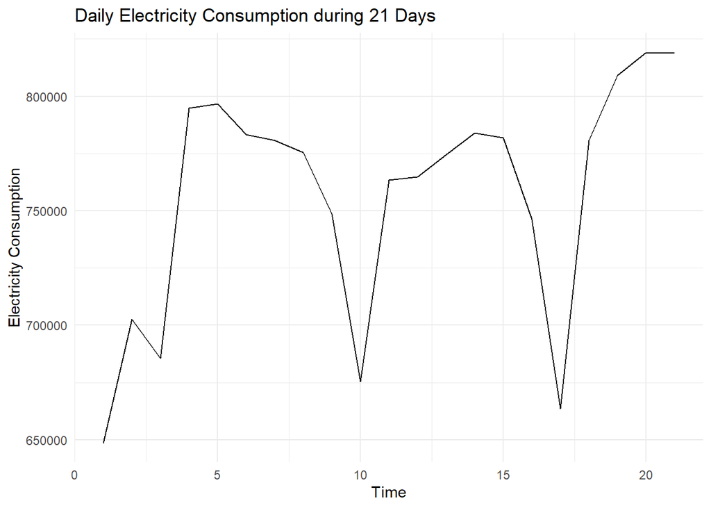

To see more clearly relationship between past days is shown by lag graph, mean of consumption according to days,ACF and, PACF graph.

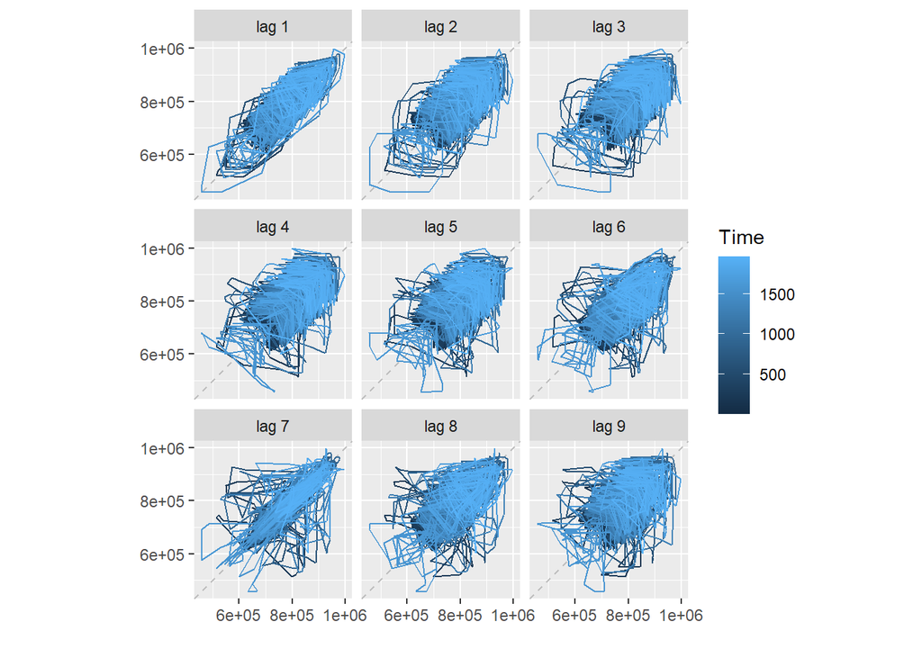

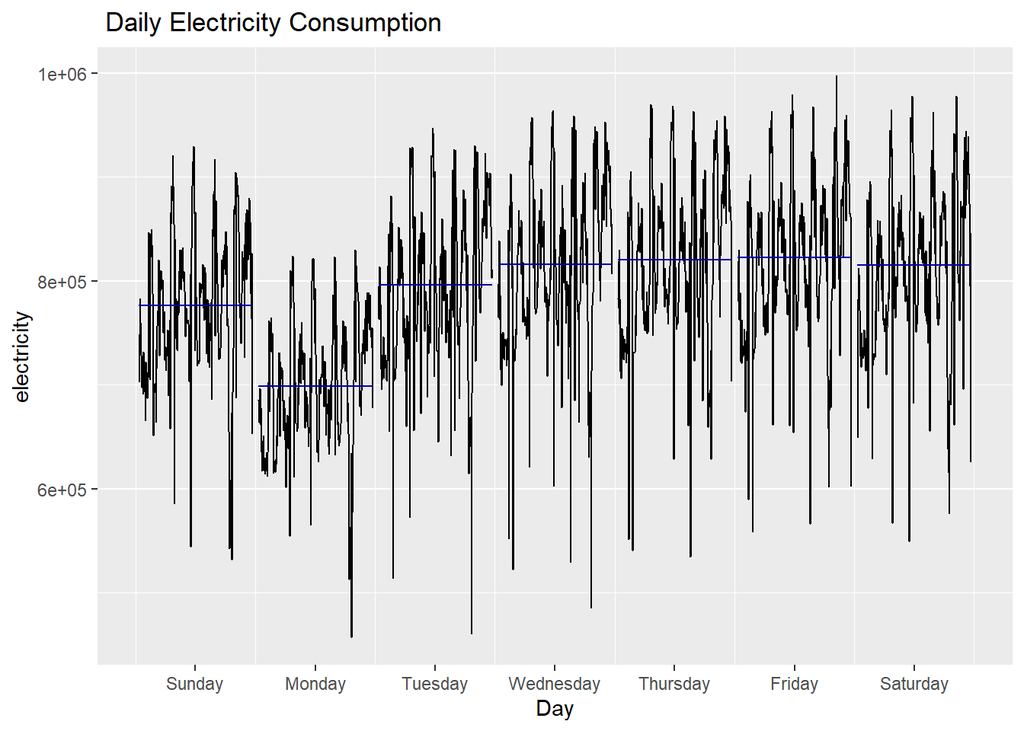

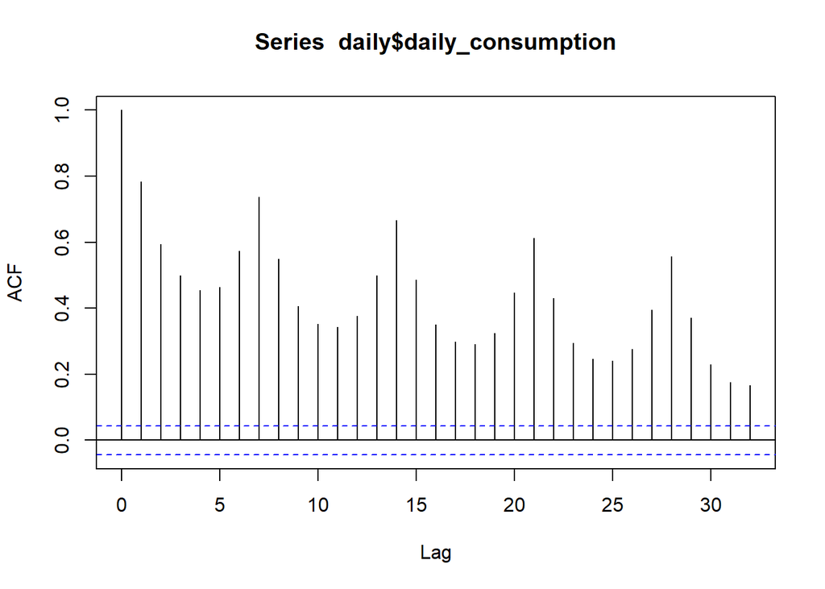

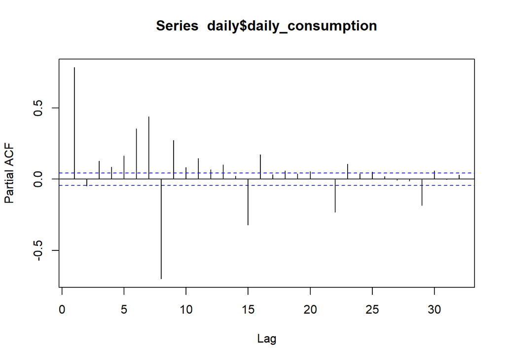

The correlation between lag 7 is significantly high, therefore, we can say that there is a season effect of day.

```
## [1] "the additive model"
```

```
##
## #######################################
## # KPSS Unit Root / Cointegration Test #
## #######################################
##
## The value of the test statistic is: 0.0137
```

```
## [1] "the multiplicative model"
```

```
##
## #######################################
## # KPSS Unit Root / Cointegration Test #
## #######################################
##
## The value of the test statistic is: 0.0181
```

By comparing KPSS unit test values of additive test method and multiplicative method, the additive method gives more stationary serie therefore, the additive model used for decomposition.

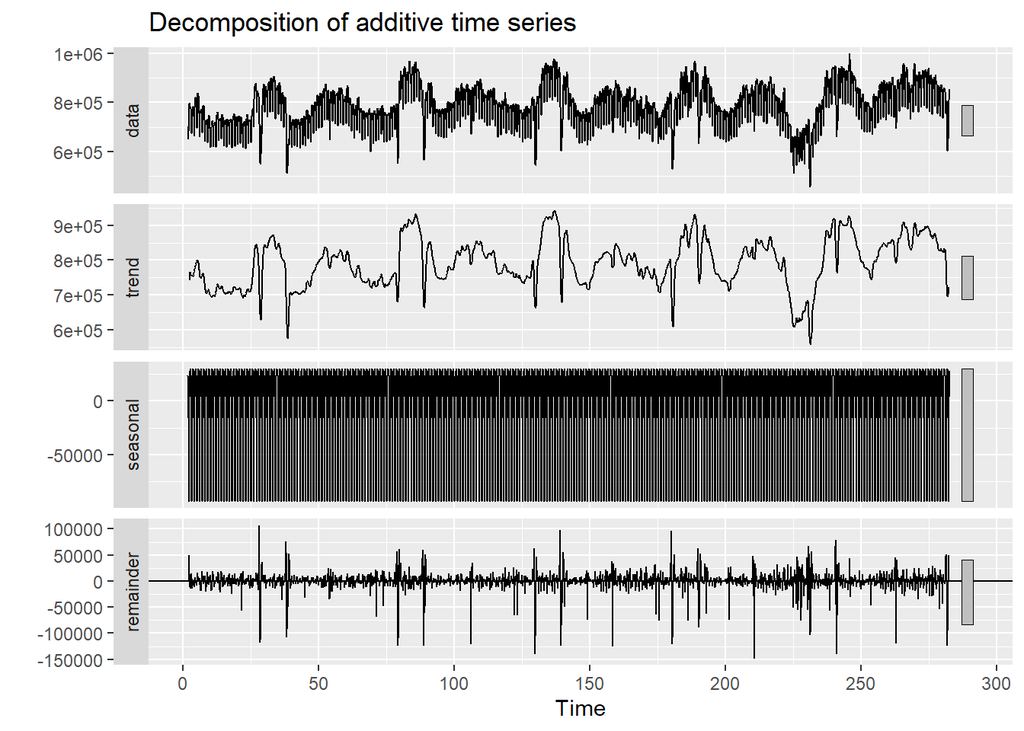

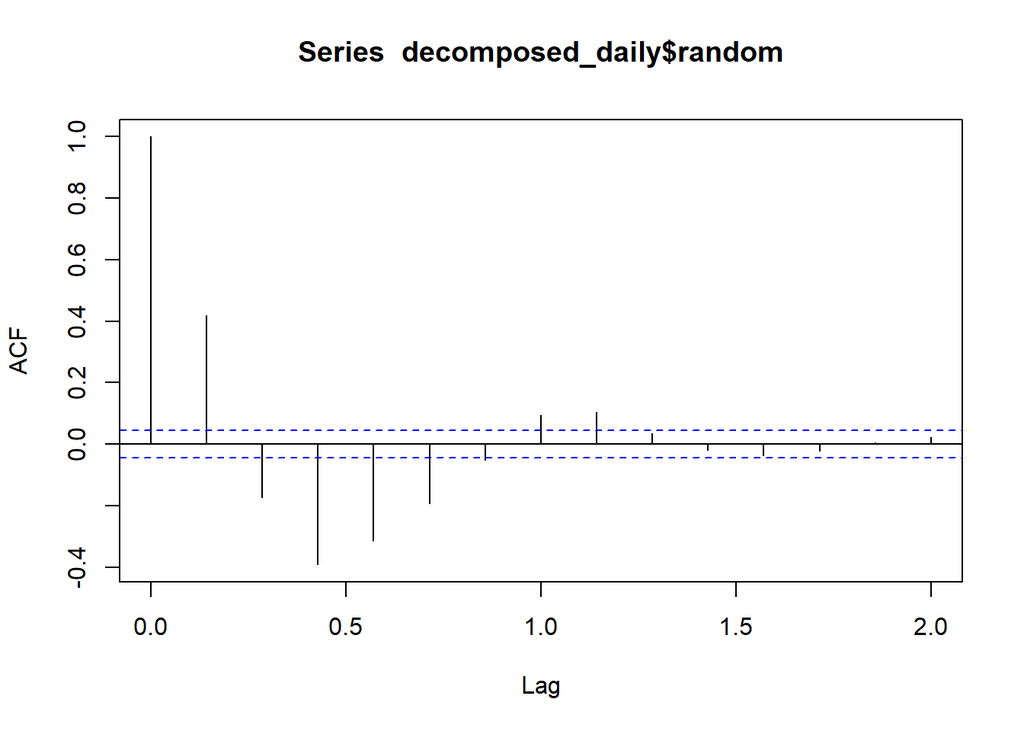

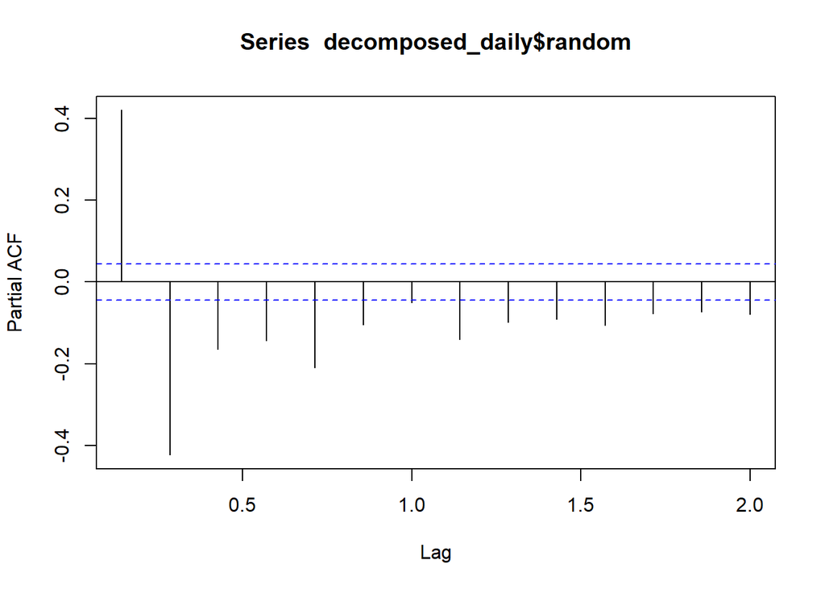

After subtracting seasonal component and trend component, it is observed that ACF shows sinusoidal geometric shape and there is sharp decrease after lag 1 in the PACF graph therefore AR model can be suitable.

### Weekly Electricity Consumption

The weekly consumption is calculated by average consumption of weeks since a year does not start on Monday and end on Sunday. By observing the graph, it can be said that varinace is not constant, therefore, to get more healthy result for model applying tranformation can be good idea, however, I did not use transormation since aim of this step is observing seasonality.

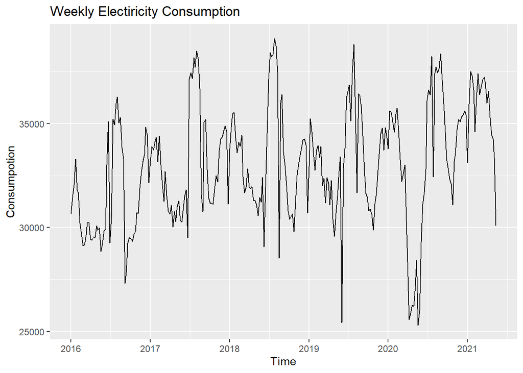

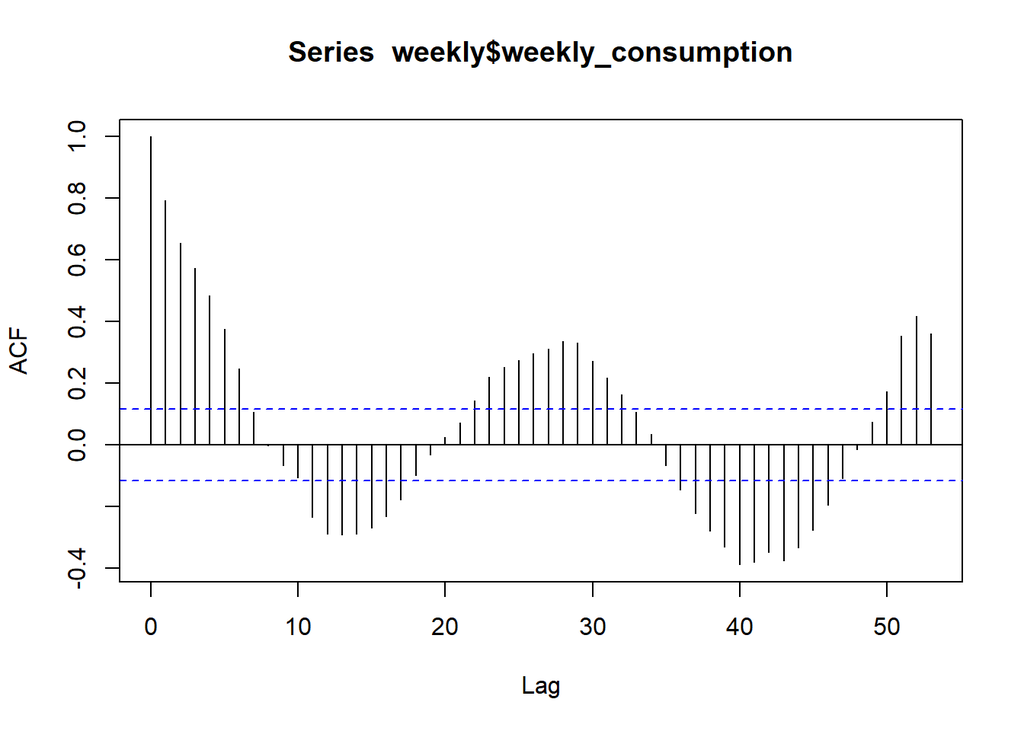

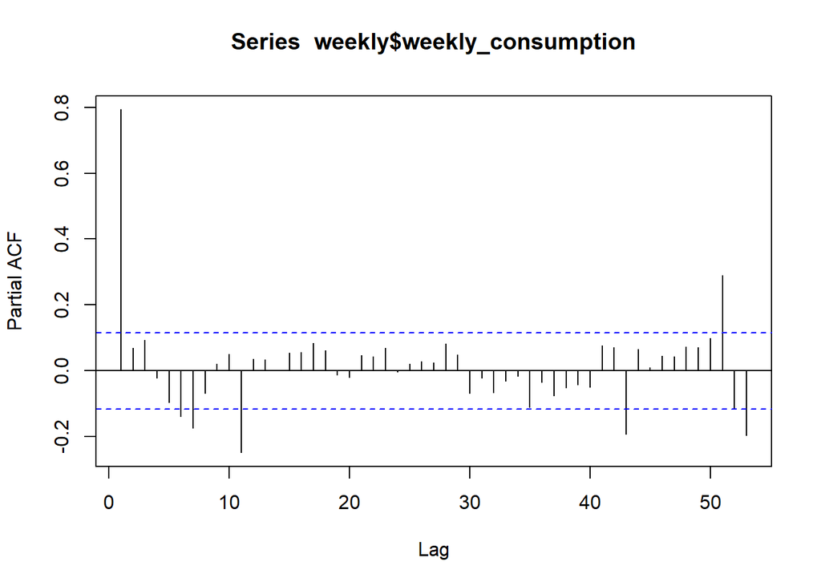

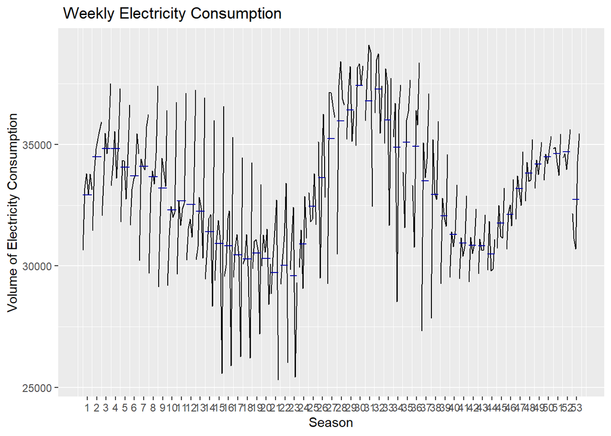

```
## [1] "the additive model"
```

```
##
## #######################################
## # KPSS Unit Root / Cointegration Test #
## #######################################
##
## The value of the test statistic is: 0.073
```

```
## [1] "the multiplicative model"
```

```
##
## #######################################
## # KPSS Unit Root / Cointegration Test #
## #######################################
##
## The value of the test statistic is: 0.067
```

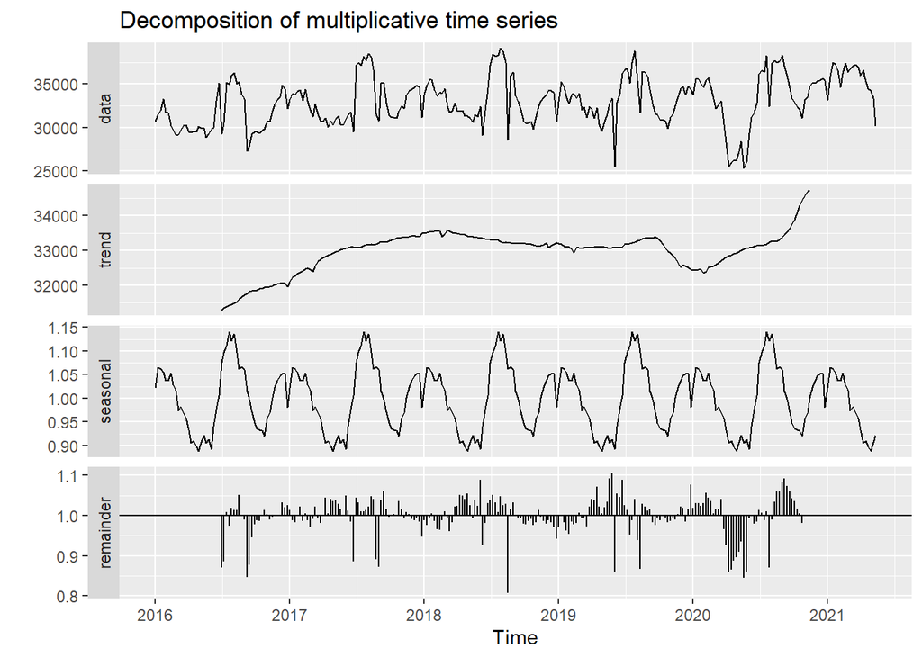

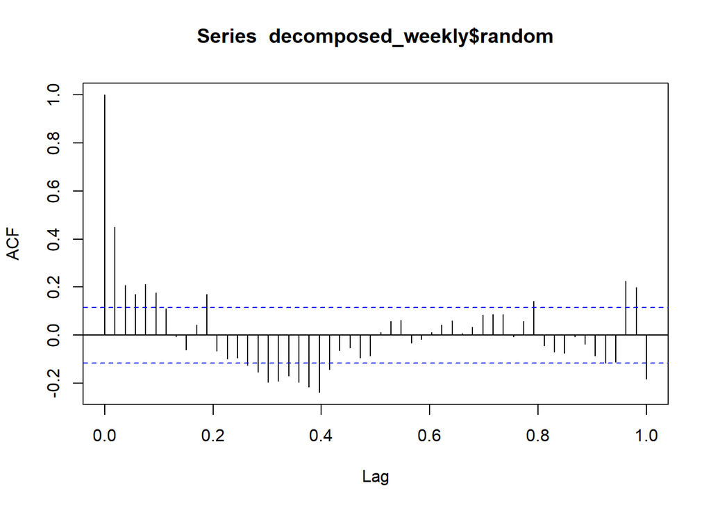

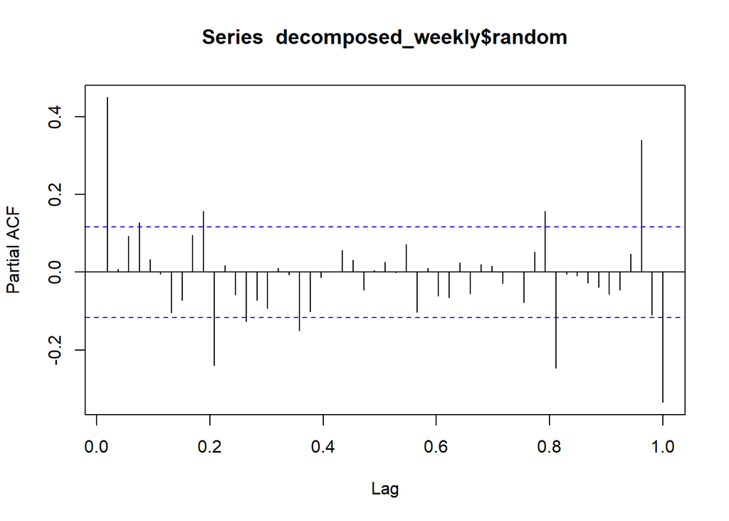

The increasing varinace was mentioned above, the effect pf increasing varinace was observed in decompositon models, since multiplicative model can handle with increasing varinace, it gave more stationary series.

### Monthly Electricity Consumption

The monthly electricity consumotion daata is prepared by average consumption since the days in month change. There is a pattern in the data which is mentioned before. The electricity consumption tends to increase during the winter and summer. The graph al shows more clear that there is a trend during the years.

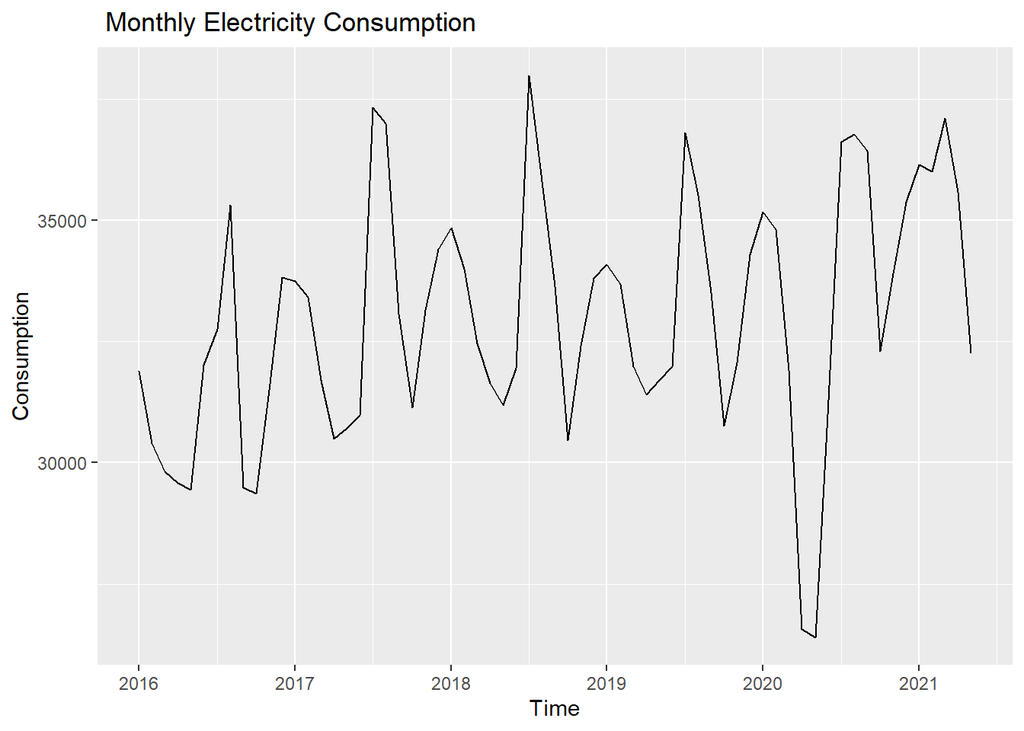

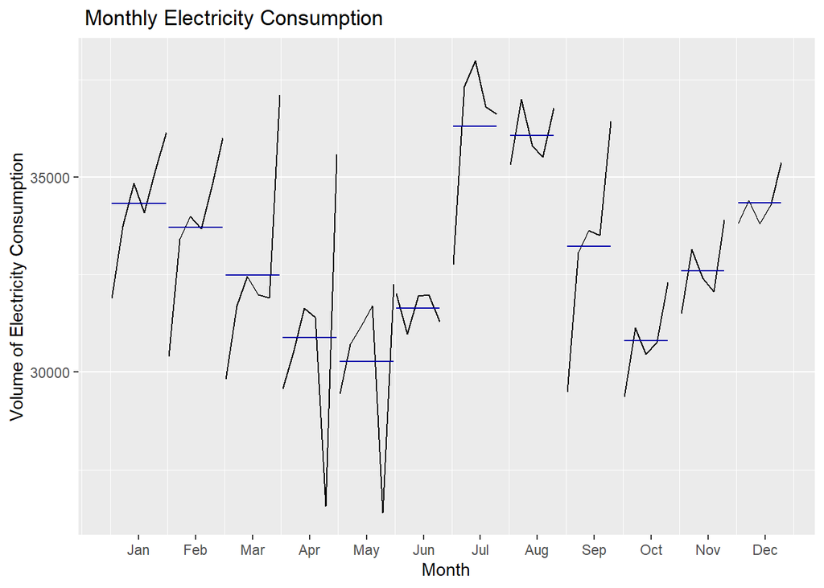

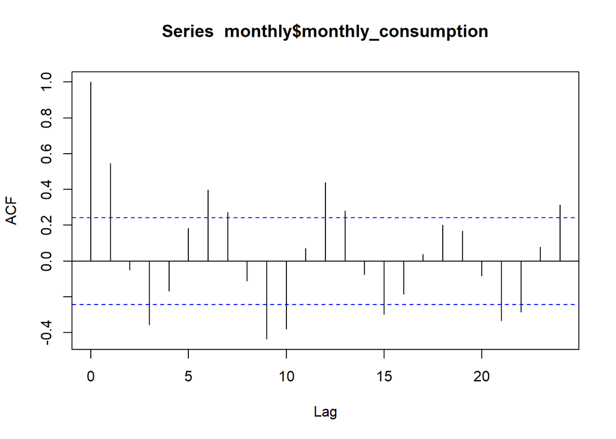

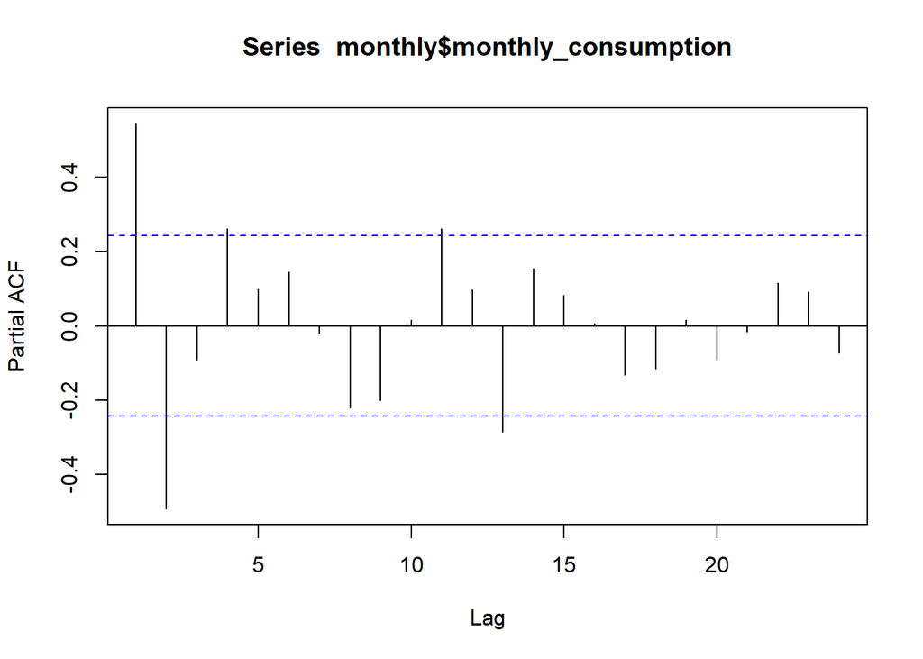

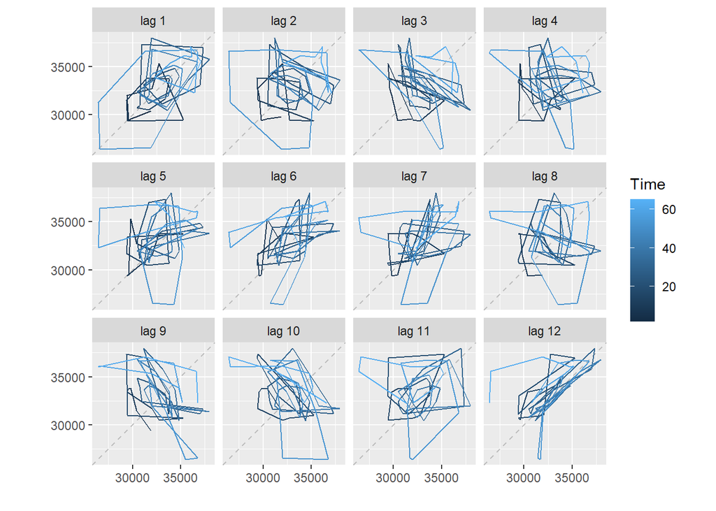

By observing lag plot, ACF and, PACF, the lag 12 has high correlation and it shows season effect.

```
## [1] "the additive model"
```

```
##
## #######################################
## # KPSS Unit Root / Cointegration Test #
## #######################################
##
## The value of the test statistic is: 0.0553
```

```
## [1] "the multiplicative model"
```

```
##
## #######################################
## # KPSS Unit Root / Cointegration Test #
## #######################################
##
## The value of the test statistic is: 0.0501
```

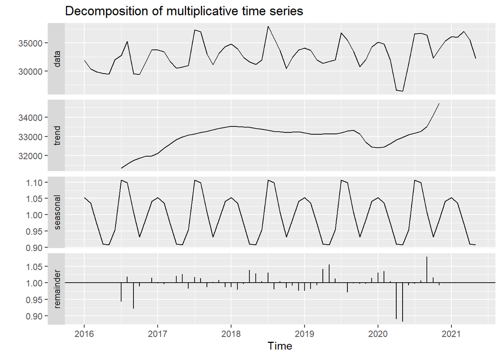

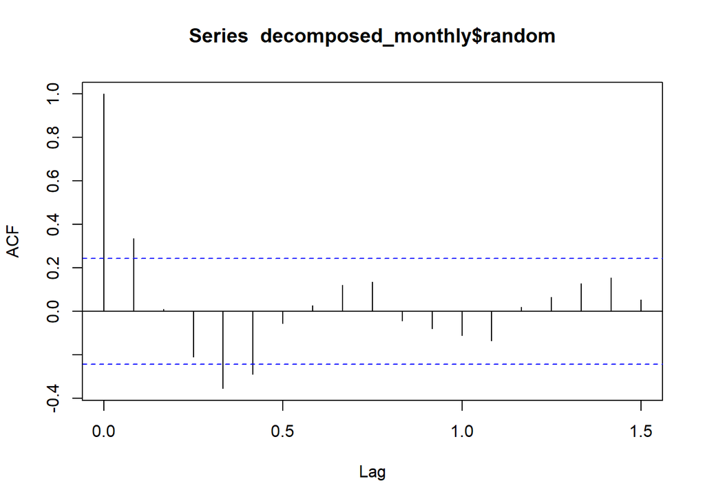

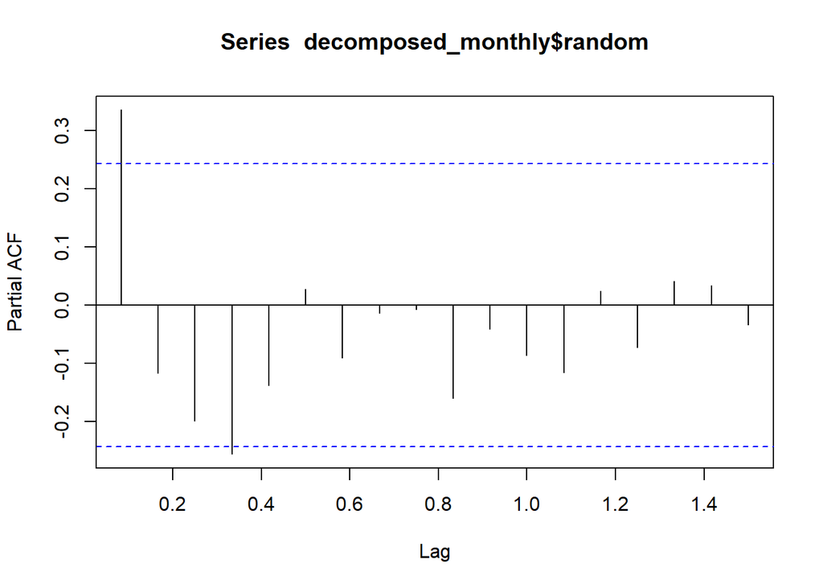

The multiplicative method gives more stationary results like weekly data, since there is also increasing variance,however, It is not as significant as weekly data. The effect of changes in conditions is more significantly observable in weekly data.

As a result, the hour and day effect is clear in the data. Moreover, the average consumption is clearly depend on the month In summer and winter months, consumotion is increasing.

## Hourly and Daily Decomposition

```
##
## #######################
## # KPSS Unit Root Test #
## #######################
##
## Test is of type: mu with 18 lags.
##
## Value of test-statistic is: 13.2336
##
## Critical value for a significance level of:
##                 10pct  5pct 2.5pct  1pct
## critical values 0.347 0.463  0.574 0.739
```

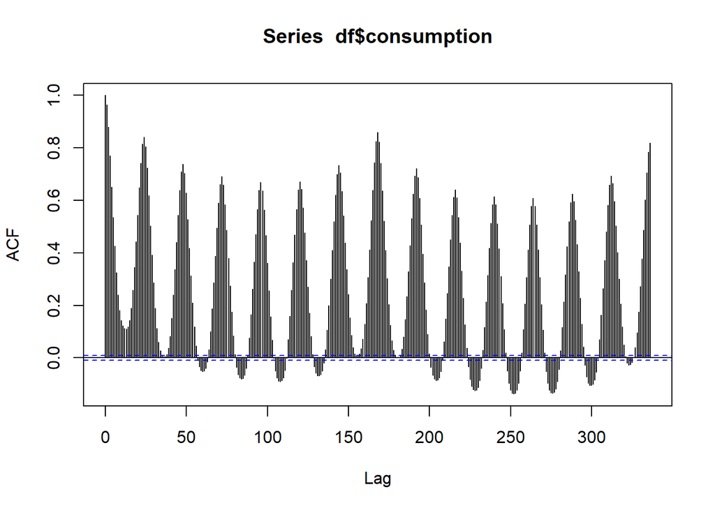

### Addtive and Multiplicative Decomposition

In this part the simple decomposition are used based on 24*7 frequency. However, the simple methods use one seasonal component and in this case, it is not properly suitable.

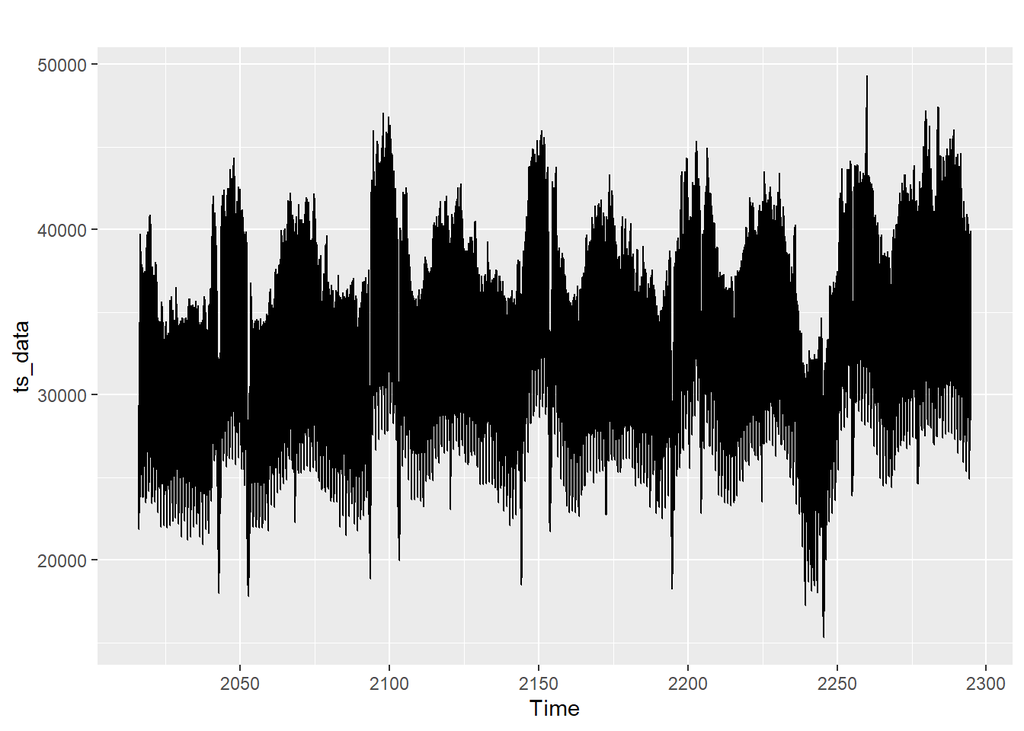

```
## [1] "the additive model"
```

```
##
## #######################################
## # KPSS Unit Root / Cointegration Test #
## #######################################
##
## The value of the test statistic is: 0.002
```

```
## [1] "the multiplicative model"
```

```
##
## #######################################
## # KPSS Unit Root / Cointegration Test #
## #######################################
##
## The value of the test statistic is: 0.0587
```

Both method is enough to get stationary serie according to KPSS test, however, additive method is more stationary. Therefore, I continue with additive decomposition model.

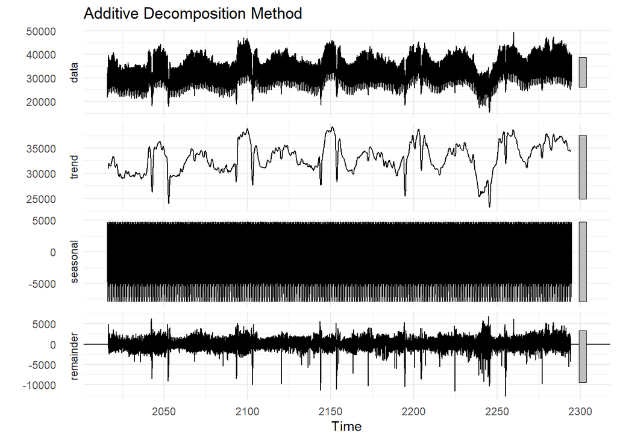

When the ACF and PACH graphs are observed, the seasonal effect is still observable.

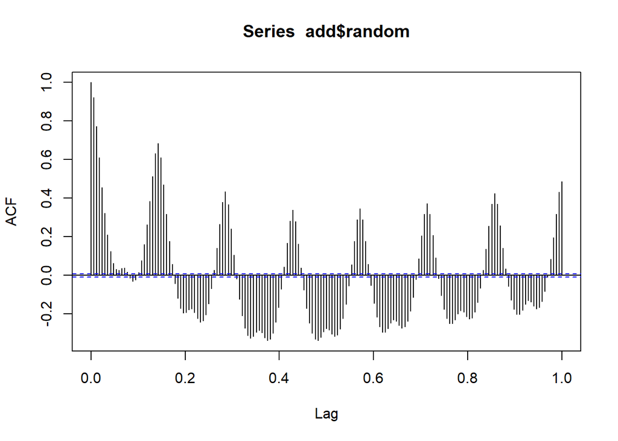

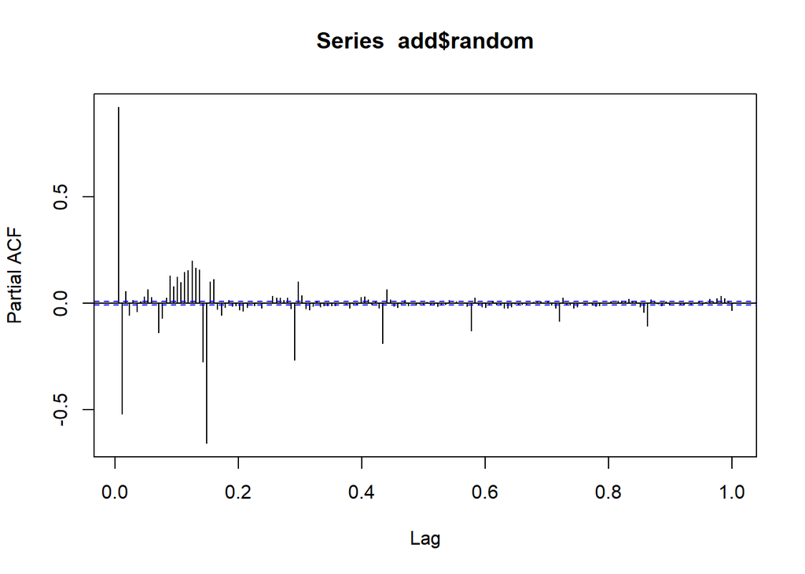